# statistics

*solution_03_central_limit_theorem/02_normal/09_bounds_from_centralarea_v2*

[video (using z-table)](https://vimeo.com/531935144)

[video (using app)](https://vimeo.com/531935582): the [app](http://18.191.167.248:3838/nprob/)

First, draw a sketch. We can label the $M$ axis by adding integer multiples of 18 to 79. We know to shade the the middle because values near 79 satisfy the condition $\big|M-79\big|<d$ (regardless of the exact value of $d$). We don’t know exactly where to place the boundaries, but we know the central area is 0.26.

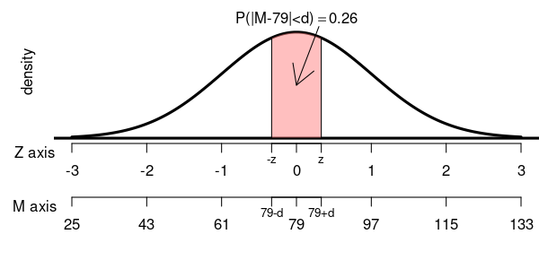

As an intermediate step, let’s find $z$ such that $P(|Z|<z)=0.26$. First, we need to evaluate $P(Z<z)$.

$$\begin{aligned}
P(Z<z) &= \frac{1+P(|Z|<z)}{2} \\ \\
&= \frac{1+0.26}{2}\\ \\
&= 0.63
\end{aligned}$$

You could have also drawn some pictures… we know there is symmetry and all the areas should add to 1.

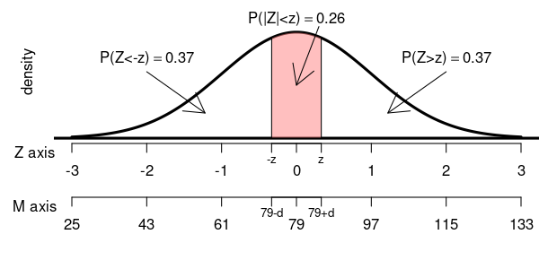

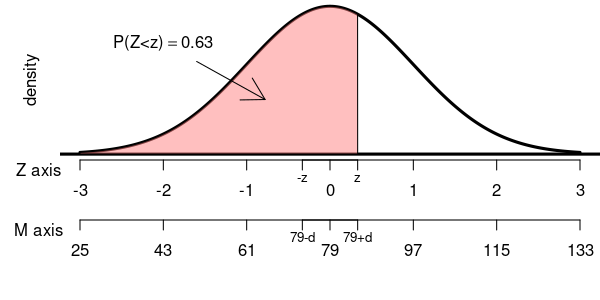

We find $z$ such that $P(Z<z)=0.63$.

By using the $z$ table we can determine $z$.

[output not shown]

Either 0.33 or 0.34 is a good estimation of $z$, and either value will lead you to an acceptable answer. Using other tools, a more accurate value can be found. I will show the work with a more accurate value.
$$z=0.3319$$

We now convert the $z$ score into a $d$ score.
$$\begin{aligned}
d &= z\sigma \\
&= (0.3319)(18) \\
&= 5.973
\end{aligned}$$

We can also visualize this with a spinner.

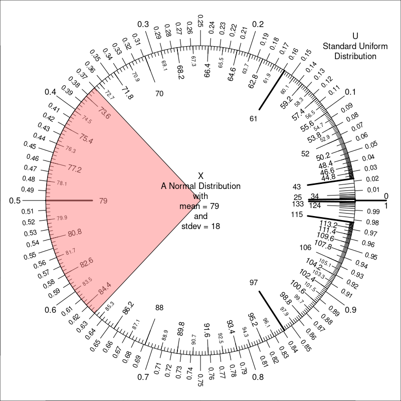

1. We determined $d=5.973$
2. It is easy to find $m_1 = 79-5.973 = 73.027$
3. It is easy to find $m_2 = 79+5.973 = 84.973$